# R Notebook

# Load

```r
library(tidyverse)
library(dplyr)
library(janitor)
library(here)
library(openmeteo)
```

# Read the Data

```r
df1 = read_csv(here("data_raw/bikes.zip"))
```

```
## Multiple files in zip: reading '202309-capitalbikeshare-tripdata.csv'
##
```

```r
print(head(df1))
```

```
## # A tibble: 6 × 13
##   ride_id          rideable_type started_at          ended_at
##   <chr>            <chr>         <dttm>              <dttm>
## 1 78909121C1F6C62C electric_bike 2023-09-07 17:17:58 2023-09-07 17:18:51
## 2 E3573C008D481AD0 electric_bike 2023-09-07 12:39:20 2023-09-07 12:49:32
## 3 68611BE6E80514B1 electric_bike 2023-09-04 16:02:31 2023-09-04 16:12:49
## 4 CB086D3D90E208AA electric_bike 2023-09-04 09:27:11 2023-09-04 09:33:43
## 5 64527B8B5EDE2129 electric_bike 2023-09-04 10:21:19 2023-09-04 10:42:23
## 6 DA6443BFB38B8C19 electric_bike 2023-09-03 20:46:37 2023-09-03 20:54:50
## # ℹ 9 more variables: start_station_name <chr>, start_station_id <dbl>,
## #   end_station_name <chr>, end_station_id <dbl>, start_lat <dbl>,
## #   start_lng <dbl>, end_lat <dbl>, end_lng <dbl>, member_casual <chr>
```

```r
print(names(df1))
```

```
##  [1] "ride_id"            "rideable_type"      "started_at"
##  [4] "ended_at"           "start_station_name" "start_station_id"
##  [7] "end_station_name"   "end_station_id"     "start_lat"
## [10] "start_lng"          "end_lat"            "end_lng"
## [13] "member_casual"
```

#Keep track of riders over time - Experiment 4 from Friday 11/3/23

```r
df2s <- df1 %>%
   select(rideable_type, member_casual, ride_id, contains("start")) %>%
   mutate(start_stop = "start") %>%
   rename(t = started_at,
          station_name = start_station_name,
          station_id = start_station_id,
          lat = start_lat,
          lng = start_lng)

df2e = df1 %>%
  select(ride_id,rideable_type,member_casual,
         contains("end")) %>%
  mutate(start_stop="stop") %>%
  rename(t=ended_at,
         station_name=end_station_name,
         station_id=end_station_id,
         lat=end_lat,
         lng=end_lng)

df2=bind_rows(df2s,df2e) %>%
  arrange(t) %>%
  mutate(rider_delta=(start_stop=="start")*2-1) %>% #change in ridership
  mutate(riders=cumsum(rider_delta)) %>%
  relocate(riders,.after=t)
```

# Start of Monday - Experiment 5 from Friday 11/6/23

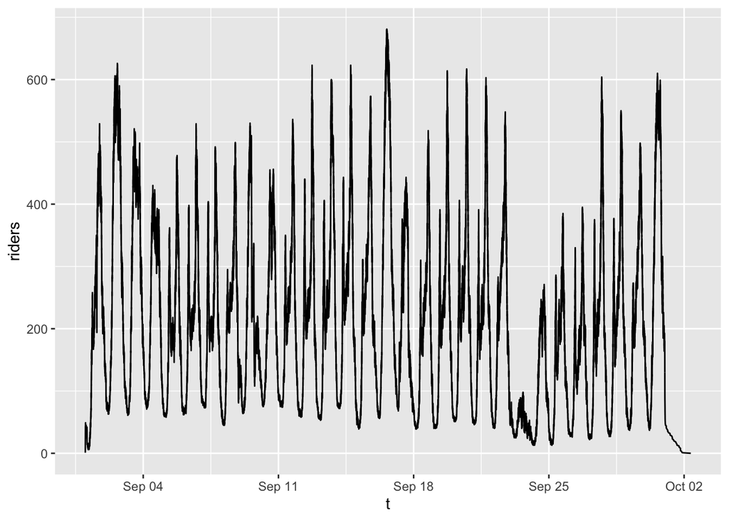

```r
# Plotting

df2 %>%
  ggplot(aes(t,riders)) +
  geom_line()
```

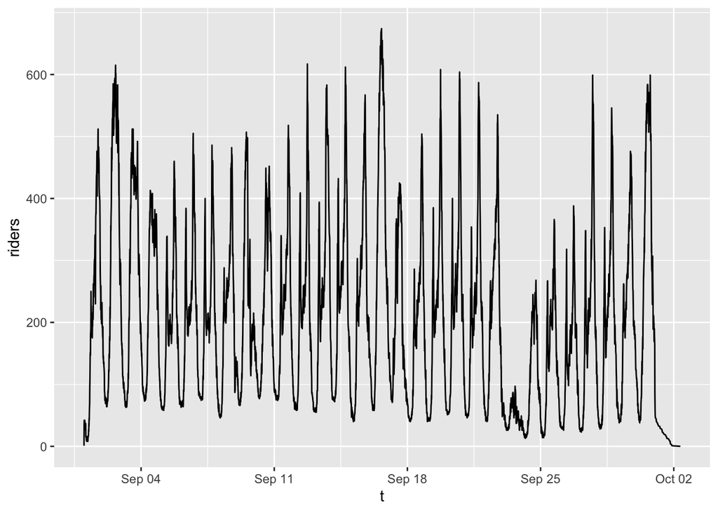

```r
df_r=df2 |>
  mutate(t_f=floor_date(t,"10 mins")) %>%
  relocate(t_f,.after=t) %>%
  slice_head(n=1,by=t_f)

df_r %>%
  ggplot(aes(t,riders)) +
  geom_line()
```

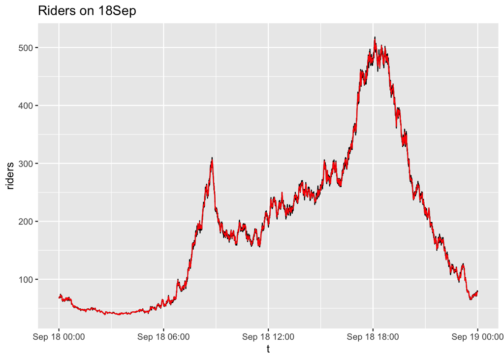

```r
df_r=df2 |>
  mutate(t_f=floor_date(t,"1 mins")) %>%
  relocate(t_f,.after=t) %>%
  slice_head(n=1,by=t_f)

p1=df2 %>%
  filter(day(t)==18) %>%
  ggplot(aes(t,riders)) +
  geom_line() +
  ggtitle("Riders on 18Sep")

p1+
  geom_line(data=df_r %>% filter(day(t)==18),
  color="red")
```

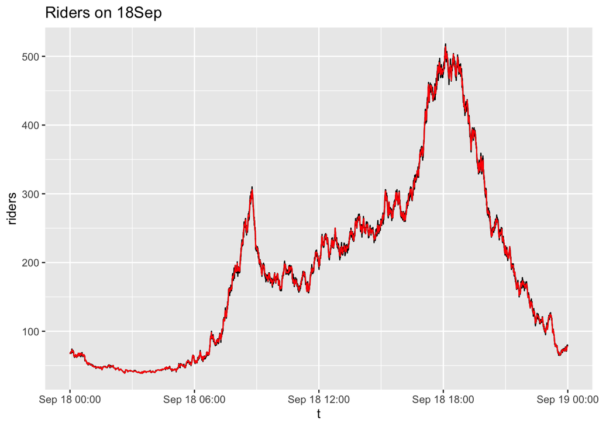

```r
p1=df2 %>%
  filter(day(t)==18) %>%
  ggplot(aes(t,riders)) +
  geom_line() +
  ggtitle("Riders on 18Sep")

p1+
  geom_line(data=df_r %>% filter(day(t)==18),
  color="red")
```

# Currently we are looking at 900,000 data points, how can we reduce this?

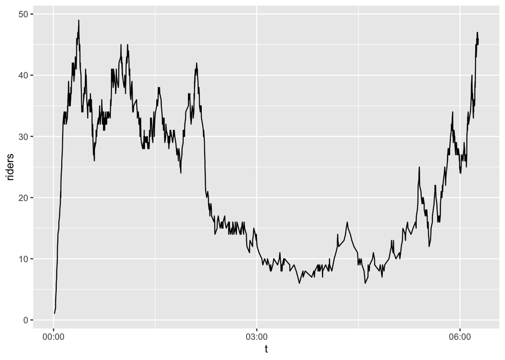

```r
df_s=df2 %>% slice_head(n=1000)
df_s %>%
  ggplot(aes(t,riders)) +
  geom_line()
```

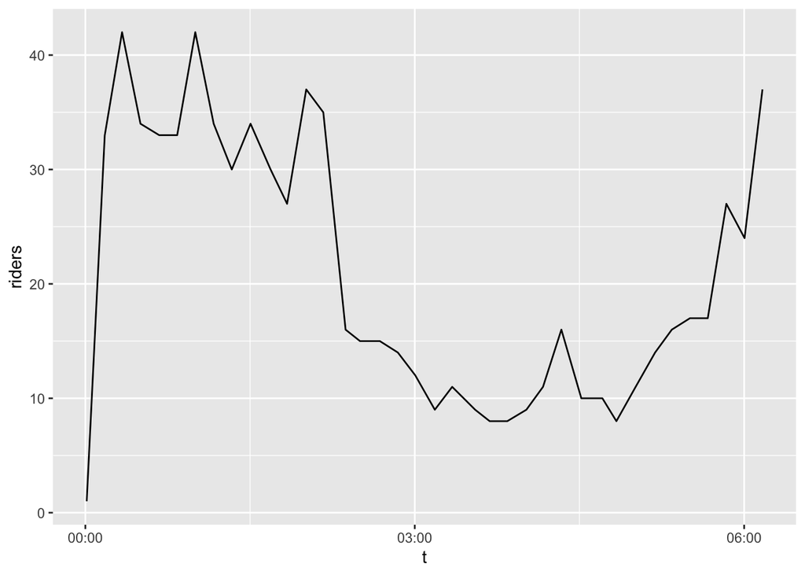

```r
# can't use the data above since it chops off the time. So to fix this we are going to round down (floor()) to the nearest 10 minutes and then slice

df_e=df_s |>
  mutate(t_f=floor_date(t,"10 mins")) %>%
  relocate(t_f,.after=t) %>%
  slice_head(n=1,by=t_f)

df_e %>%
  ggplot(aes(t,riders)) +
  geom_line()
```

#Getting Weather Data for Septemebr

```r
df_w=weather_history("Washington",
      start = "2023-09-01",
      end = "2023-09-30",
      hourly = c("apparent_temperature",
                  "wind_speed_10m",
                  "precipitation")

)
```

```
## `geocode()` has matched "Washington" to:
## Washington in Washington, D.C., United States
## Population: 601723
## Co-ordinates: c(38.89511, -77.03637)
```

```r
df_s=df2 %>% slice_sample(n=1000)
df_j=df_s %>% left_join(df_w,
          by=join_by(closest(t>=datetime)))
```

```r
df_j=df_s %>%
  left_join(df_w,by=join_by(closest(t>=datetime)))  %>%
  relocate(datetime, .after=t)
head(df_j)
```

| rideable_type | member_casual | ride_id | t | datetime | riders | station_name | station_id | lat | lng | start_stop | rider_delta | hourly_apparent_temperature | hourly_wind_speed_10m | hourly_precipitation |
| --- | --- | --- | --- | --- | --- | --- | --- | --- | --- | --- | --- | --- | --- | --- |
| classic_bike | member | A737ACFA84A719AB | 2023-09-02 22:53:46 | 2023-09-02 18:00:00 | 221 | Mount Vernon Ave & E Del Ray Ave | 31086 | 38.82595 | -77.05854 | stop | -1 | 28.0 | 10.8 | 0.0 |
| electric_bike | member | 2660FD1401AE0FAF | 2023-09-10 19:38:05 | 2023-09-10 15:00:00 | 339 | NA | NA | 38.91000 | -77.00000 | stop | -1 | 30.0 | 5.2 | 0.1 |
| electric_bike | member | D390A5E197FF0292 | 2023-09-21 22:14:42 | 2023-09-21 18:00:00 | 212 | NA | NA | 38.90000 | -77.06000 | start | 1 | 21.4 | 7.9 | 0.0 |
| classic_bike | member | 3169A89917C85EE2 | 2023-09-20 22:06:31 | 2023-09-20 18:00:00 | 210 | Westbranch & Jones Branch Dr | 32270 | 38.93109 | -77.22073 | stop | -1 | 21.4 | 5.9 | 0.0 |
| electric_bike | casual | C72A207C914DF732 | 2023-09-22 18:54:22 | 2023-09-22 14:00:00 | 379 | 20th St & Florida Ave NW | 31110 | 38.91545 | -77.04460 | start | 1 | 20.5 | 18.8 | 0.0 |
| classic_bike | casual | 4E629DEF3F959846 | 2023-09-13 18:45:51 | 2023-09-13 14:00:00 | 520 | 20th & L St NW | 31250 | 38.90358 | -77.04479 | stop | -1 | 29.8 | 6.0 | 0.1 |

```r
df_j$t[1:5]
```

```
## [1] "2023-09-02 22:53:46 UTC" "2023-09-10 19:38:05 UTC"
## [3] "2023-09-21 22:14:42 UTC" "2023-09-20 22:06:31 UTC"
## [5] "2023-09-22 18:54:22 UTC"
```

```r
df_j$datetime[1:5]
```

```
## [1] "2023-09-02 18:00:00 EDT" "2023-09-10 15:00:00 EDT"
## [3] "2023-09-21 18:00:00 EDT" "2023-09-20 18:00:00 EDT"
## [5] "2023-09-22 14:00:00 EDT"
```

```r
df2$t[1:5]
```

```
## [1] "2023-09-01 00:00:44 UTC" "2023-09-01 00:01:48 UTC"
## [3] "2023-09-01 00:01:48 UTC" "2023-09-01 00:02:03 UTC"
## [5] "2023-09-01 00:02:21 UTC"
```

```r
force_tz(df2$t[1:5],"America/New_York")
```

```
## [1] "2023-09-01 00:00:44 EDT" "2023-09-01 00:01:48 EDT"
## [3] "2023-09-01 00:01:48 EDT" "2023-09-01 00:02:03 EDT"
## [5] "2023-09-01 00:02:21 EDT"
```

```r
df2c=df2 %>% mutate(t=force_tz(t,tzone="America/New_York"))
df_s2=df2c %>%
  slice_sample(n=1000)
df_j2 = df_s2 %>%
  left_join(df_w,by=join_by(closest(t>=datetime)))  %>%
  relocate(datetime, .after=t)

head(df_j2)
```

| rideable_type | member_casual | ride_id | t | datetime | riders | station_name | station_id | lat | lng | start_stop | rider_delta | hourly_apparent_temperature | hourly_wind_speed_10m | hourly_precipitation |
| --- | --- | --- | --- | --- | --- | --- | --- | --- | --- | --- | --- | --- | --- | --- |
| classic_bike | casual | 9DD86AA881C1B39B | 2023-09-10 09:49:25 | 2023-09-10 09:00:00 | 214 | Florida Ave & R St NW | 31503 | 38.91260 | -77.01350 | start | 1 | 25.1 | 10.2 | 0.3 |
| electric_bike | member | 4420A0135AA10C52 | 2023-09-05 08:56:12 | 2023-09-05 08:00:00 | 295 | M St & Pennsylvania Ave NW | 31246 | 38.90507 | -77.05686 | start | 1 | 31.1 | 12.2 | 0.0 |
| electric_bike | member | 9FB95B58B1605D3C | 2023-09-01 11:47:29 | 2023-09-01 11:00:00 | 244 | Vermont Ave & I St NW | 31291 | 38.90116 | -77.03439 | start | 1 | 25.3 | 7.1 | 0.0 |
| electric_bike | member | 6FCE2286863E262E | 2023-09-25 22:12:31 | 2023-09-25 22:00:00 | 99 | Rhode Island Ave & V St NE | 31513 | 38.91815 | -77.00475 | stop | -1 | 15.5 | 11.8 | 0.0 |
| classic_bike | member | 67C04D68B195F010 | 2023-09-26 12:55:05 | 2023-09-26 12:00:00 | 162 | Independence Ave & L'Enfant Plaza SW/DOE | 31633 | 38.88731 | -77.02576 | stop | -1 | 15.5 | 16.5 | 0.0 |
| electric_bike | member | C1B8E3FCB36F6DB7 | 2023-09-13 18:14:00 | 2023-09-13 18:00:00 | 569 | NA | NA | 38.91000 | -77.07000 | start | 1 | 27.6 | 1.1 | 0.0 |

```r
dfc=df2c %>%
  left_join(df_w, by=join_by(closest(t>=datetime))) %>%
  relocate(datetime, .after=t)  %>%
  rename(atempt=hourly_apparent_temperature,
         wind=hourly_wind_speed_10m,
         prec=hourly_precipitation)
```

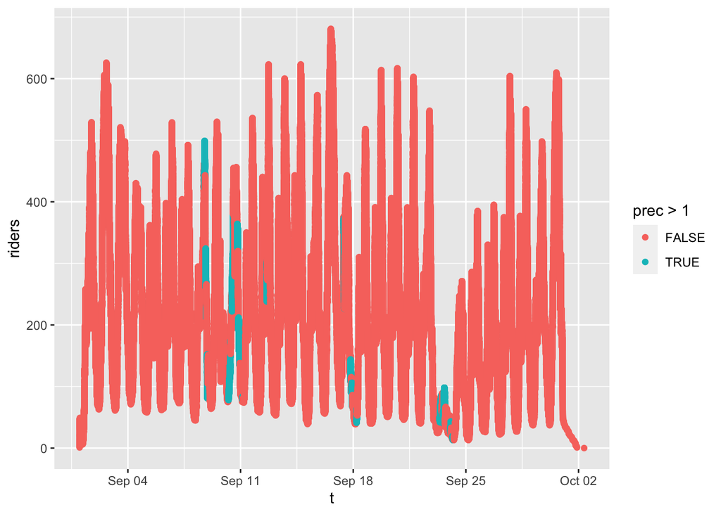

```r
p2=dfc %>%
  ggplot(aes(x=t,y=riders,color=prec>1)) +
  geom_point()
p2
```

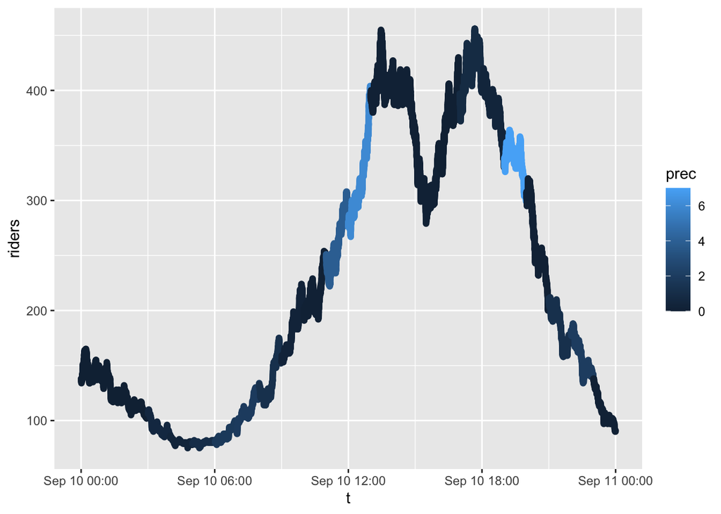

```r
p2=dfc %>%
  filter(day(t)==10) %>%
  ggplot(aes(x=t,y=riders,color=prec)) +
  geom_point()
p2
```

###Answering the questions

Easy: Use summarise to create a dataframe that counts the number of “starts” from each station ID Use summarise to create a dataframe that counts the number of “ends” from each station ID.

```r
library(dplyr)
library(lubridate)

dfb <- df1 %>%
  filter(started_at <= ended_at & month(started_at) == 9)
```

```r
df_startcount <- dfb %>%
  group_by(start_station_id) %>%
  count(name="start_count")
print(df_startcount)
```

```
## # A tibble: 739 × 2
## # Groups:   start_station_id [739]
##    start_station_id start_count
##               <dbl>       <int>
##  1            30200        1068
##  2            30201        1216
##  3            31000         403
##  4            31002         461
##  5            31003         560
##  6            31004         193
##  7            31005         714
##  8            31006         569
##  9            31007         595
## 10            31009         271
## # ℹ 729 more rows
```

```r
df_endcount <- dfb %>%
  group_by(end_station_id) %>%
  count(name="end_count")
print(df_endcount)
```

```
## # A tibble: 739 × 2
## # Groups:   end_station_id [739]
##    end_station_id end_count
##             <dbl>     <int>
##  1          30200      1363
##  2          30201      1272
##  3          31000       405
##  4          31002       460
##  5          31003       555
##  6          31004       194
##  7          31005       706
##  8          31006       562
##  9          31007       577
## 10          31009       269
## # ℹ 729 more rows
```

Medium Problems:

Join those two dataframes (in an appropriate way)

```r
joined_df <- left_join(df_startcount, df_endcount, by = c("start_station_id" = "end_station_id"))
print(joined_df)
```

```
## # A tibble: 739 × 3
## # Groups:   start_station_id [739]
##    start_station_id start_count end_count
##               <dbl>       <int>     <int>
##  1            30200        1068      1363
##  2            30201        1216      1272
##  3            31000         403       405
##  4            31002         461       460
##  5            31003         560       555
##  6            31004         193       194
##  7            31005         714       706
##  8            31006         569       562
##  9            31007         595       577
## 10            31009         271       269
## # ℹ 729 more rows
```

```r
joined_df$net_gain <- joined_df$start_count - joined_df$end_count
print(joined_df)
```

```
## # A tibble: 739 × 4
## # Groups:   start_station_id [739]
##    start_station_id start_count end_count net_gain
##               <dbl>       <int>     <int>    <int>
##  1            30200        1068      1363     -295
##  2            30201        1216      1272      -56
##  3            31000         403       405       -2
##  4            31002         461       460        1
##  5            31003         560       555        5
##  6            31004         193       194       -1
##  7            31005         714       706        8
##  8            31006         569       562        7
##  9            31007         595       577       18
## 10            31009         271       269        2
## # ℹ 729 more rows
```

Stretch goals:

Perform exploratory analysis (visualization??) on the resultant dataframe:

```r
# Summary statistics
summary(joined_df$net_gain)
```

```
##    Min. 1st Qu.  Median    Mean 3rd Qu.    Max.
##   -2527      -7       1       0      10     770
```

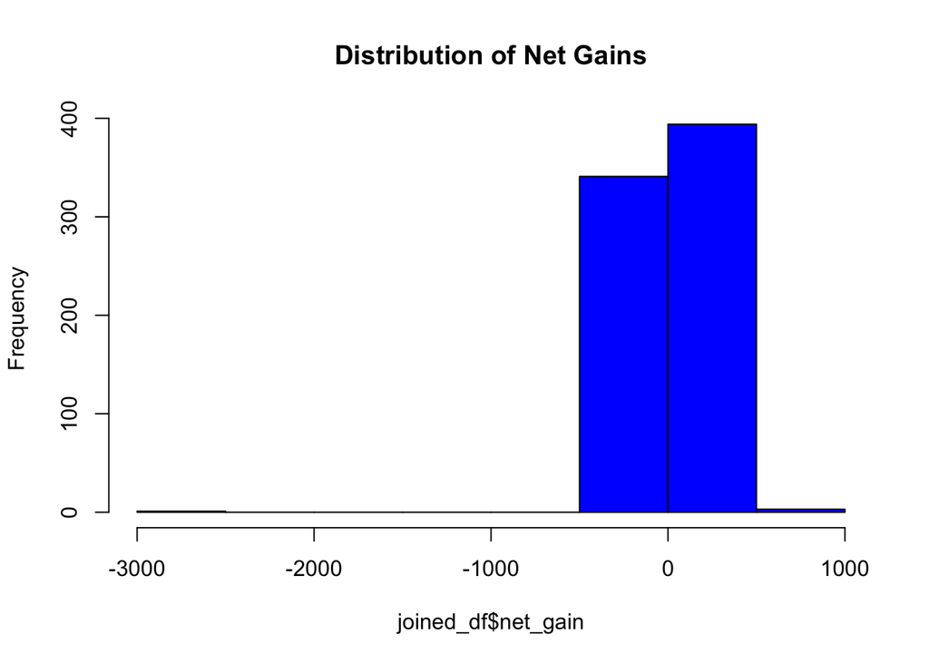

```r
# Histogram
hist(joined_df$net_gain, breaks = 10, col = "blue", main = "Distribution of Net Gains")
```

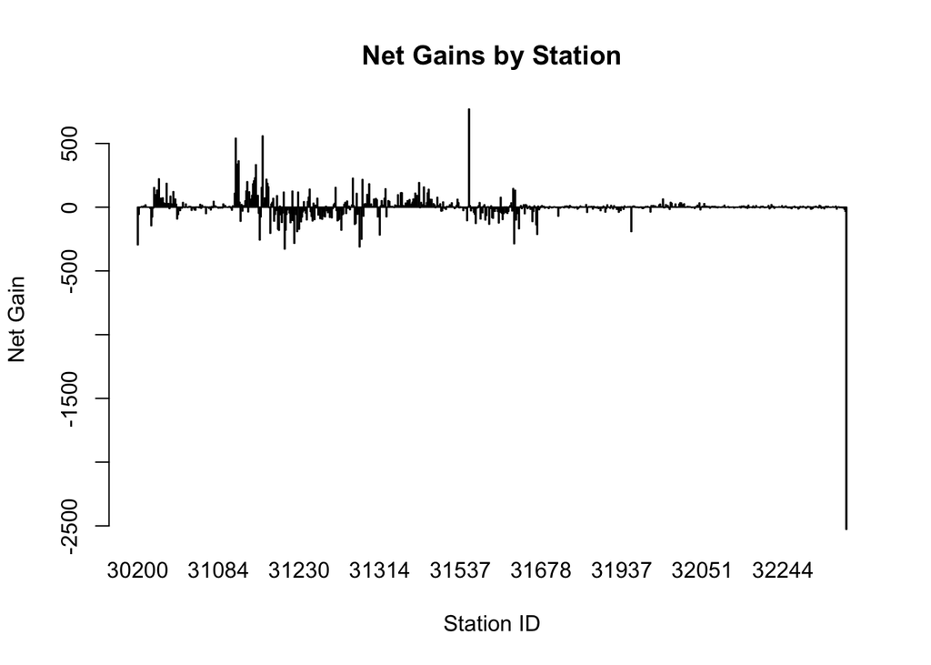

```r
# Bar plot
barplot(joined_df$net_gain, names.arg = joined_df$start_station_id, col = "green",
        xlab = "Station ID", ylab = "Net Gain", main = "Net Gains by Station")
```

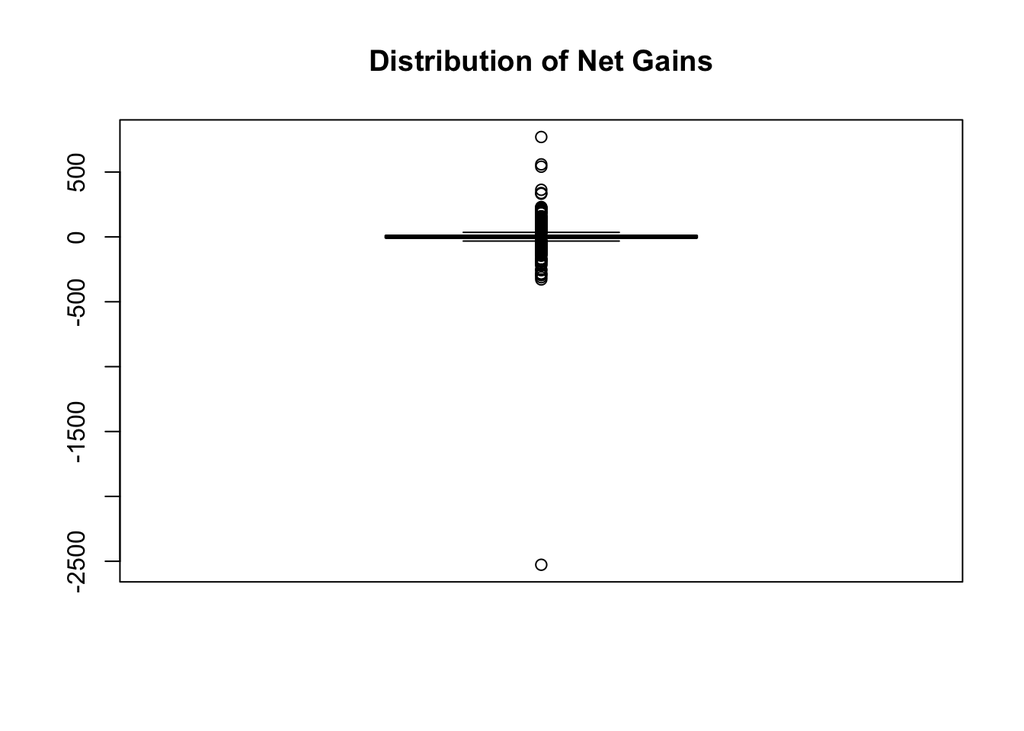

```r
# Box plot
boxplot(joined_df$net_gain, col = "orange", main = "Distribution of Net Gains")
```